# New York City Airbnb Data Analysis, Visualization and Prediction

Johnny Ji

2022-05-28

# 1 Introduction

### 1.1 What is Airbnb?

[figure not shown]

```r
 knitr::include_graphics("./picture/airbnb.jpg")
```

```r
 library(vembedr)
 embed_youtube("dA2F0qScxrI")
```

[video not shown]

Airbnb is an American company that operates an online marketplace for lodging, primarily homestays for vacation rentals, and tourism activities. Based in San Francisco, California, the platform is accessible via website and mobile app. Airbnb does not own any of the listed properties; instead, it profits by receiving commission from each booking. Airbnb began in 2008 when two designers who had space to share hosted three travelers looking for a place to stay. Now, millions of hosts and travelers choose to create a free Airbnb account so they can list their space and book unique accommodations anywhere in the world. And Airbnb experience hosts share their passions and interests with both travelers and locals.

### 1.2 The goal of this project

Our goal is to predict the New York City Airbnb listing prices by using various machine learning models.In the end, I want to select the models with lowest MSE.

# 2 Loading the data

### 2.1 loading the data

The dataset we will be using for our analysis is the dataset New York City Airbnb Open Data from Kaggle.

```r
bnb <- read_delim("./data/AB_NYC_2019.csv", delim = ",")
```

### 2.2 Check the dim and type of varibles

```r
dims <- dim(bnb)
dims
```

```
## [1] 48895    16
```

```r
str(bnb)
```

```
## spec_tbl_df [48,895 x 16] (S3: spec_tbl_df/tbl_df/tbl/data.frame)
##  $ id                            : num [1:48895] 2539 2595 3647 3831 5022 ...
##  $ name                          : chr [1:48895] "Clean & quiet apt home by the park" "Skylit Midtown Castle" "THE VILLAGE OF HARLEM....NEW YORK !" "Cozy Entire Floor of Brownstone" ...
##  $ host_id                       : num [1:48895] 2787 2845 4632 4869 7192 ...
##  $ host_name                     : chr [1:48895] "John" "Jennifer" "Elisabeth" "LisaRoxanne" ...
##  $ neighbourhood_group           : chr [1:48895] "Brooklyn" "Manhattan" "Manhattan" "Brooklyn" ...
##  $ neighbourhood                 : chr [1:48895] "Kensington" "Midtown" "Harlem" "Clinton Hill" ...
##  $ latitude                      : num [1:48895] 40.6 40.8 40.8 40.7 40.8 ...
##  $ longitude                     : num [1:48895] -74 -74 -73.9 -74 -73.9 ...
##  $ room_type                     : chr [1:48895] "Private room" "Entire home/apt" "Private room" "Entire home/apt" ...
##  $ price                         : num [1:48895] 149 225 150 89 80 200 60 79 79 150 ...
##  $ minimum_nights                : num [1:48895] 1 1 3 1 10 3 45 2 2 1 ...
##  $ number_of_reviews             : num [1:48895] 9 45 0 270 9 74 49 430 118 160 ...
##  $ last_review                   : Date[1:48895], format: "2018-10-19" "2019-05-21" ...
##  $ reviews_per_month             : num [1:48895] 0.21 0.38 NA 4.64 0.1 0.59 0.4 3.47 0.99 1.33 ...
##  $ calculated_host_listings_count: num [1:48895] 6 2 1 1 1 1 1 1 1 4 ...
##  $ availability_365              : num [1:48895] 365 355 365 194 0 129 0 220 0 188 ...
##  - attr(*, "spec")=
##   .. cols(
##   ..   id = col_double(),
##   ..   name = col_character(),
##   ..   host_id = col_double(),
##   ..   host_name = col_character(),
##   ..   neighbourhood_group = col_character(),
##   ..   neighbourhood = col_character(),
##   ..   latitude = col_double(),
##   ..   longitude = col_double(),
##   ..   room_type = col_character(),
##   ..   price = col_double(),
##   ..   minimum_nights = col_double(),
##   ..   number_of_reviews = col_double(),
##   ..   last_review = col_date(format = ""),
##   ..   reviews_per_month = col_double(),
##   ..   calculated_host_listings_count = col_double(),
##   ..   availability_365 = col_double()
##   .. )
##  - attr(*, "problems")=<externalptr>
```

There are 48895 observations and 16 predictors in BNB data.

- id - ID of listing
- name - Name of listing
- host_id - ID of the host
- host_name - Name of the host
- neighbourhood_group - Neighbourhood group name
- neighbourhood - Neighbouthood area name
- latitude - Latitude of the room
- longitude - Longitude of the room
- room_type - Type of room (Consist of 3 categories)
- price - Price In Dollars
- minimum_nights - Number of minimum nights allowed
- number_of_reviews - Number of reviews about a particular room
- last_review - Date on which last review was given
- reviews_per_month - Its a ratio(no. of reviews/30)
- callculated_host_listings_count - Amount of listing per host
- availability_365 - Number of days in a year when bookings are available

# 3 Data cleaning

### 3.1 Drop useless variables

We have some variables that don’t carry any useful information and hence wont’ be used in predictive models:

- id - ID of listing
- host_id - ID of the host
- last_review - Date on which last review was given

```r
names_to_delete <- c("id", "host_id","last_review")
bnb[names_to_delete] <- NULL
```

### 3.1 Checking missing variables

```r
sum(is.na(bnb))
```

```
## [1] 10089
```

```r
colSums(is.na(bnb))
```

```
##                           name                      host_name
##                             16                             21
##            neighbourhood_group                  neighbourhood
##                              0                              0
##                       latitude                      longitude
##                              0                              0
##                      room_type                          price
##                              0                              0
##                 minimum_nights              number_of_reviews
##                              0                              0
##              reviews_per_month calculated_host_listings_count
##                          10052                              0
##               availability_365
##                              0
```

From abrove, we can see we have 10089 missing values, We start to deal with the missing variables.

```r
bnb <- bnb[(bnb$price!=0),]
bnb[is.na(bnb$reviews_per_month),'reviews_per_month'] <- 0
```

Check the missing value again

```r
colSums(is.na(bnb))
```

```
##                           name                      host_name
##                             16                             21
##            neighbourhood_group                  neighbourhood
##                              0                              0
##                       latitude                      longitude
##                              0                              0
##                      room_type                          price
##                              0                              0
##                 minimum_nights              number_of_reviews
##                              0                              0
##              reviews_per_month calculated_host_listings_count
##                              0                              0
##               availability_365
##                              0
```

```r
sum(is.na(bnb))
```

```
## [1] 37
```

After dealing with the missing value, we have 37 missing value left, we eliminate most of the missing values.But they are host_name, or name which will not affect the process of prediction.

# 3 Exploratory Data Analysis

# 3.1 Histogram of price

Since the price is our prime goal, we should show its Histogram

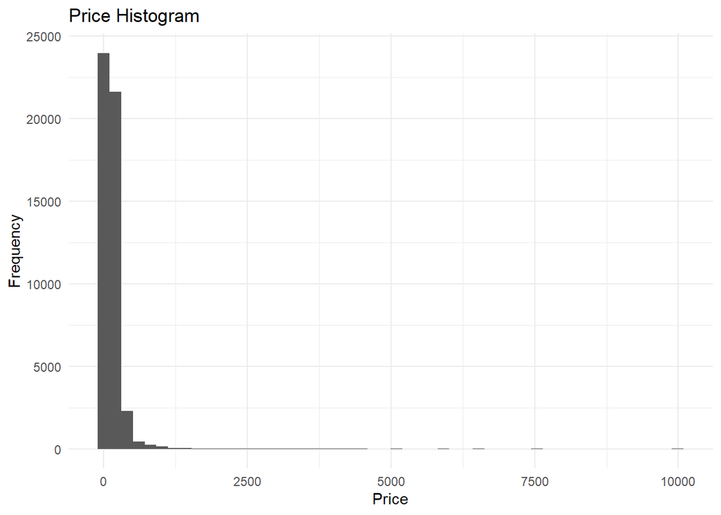

```r
ggplot(data = bnb, mapping = aes(x = price)) +
         geom_histogram(bins = 50, size = 1.5) +
         theme_minimal() +
         ylab("Frequency") +
         xlab("Price") +
         ggtitle("Price Histogram")
```

From the graph, we can tell that distribution is very skewed. In this case , we should utilize the logarithmic transformation.

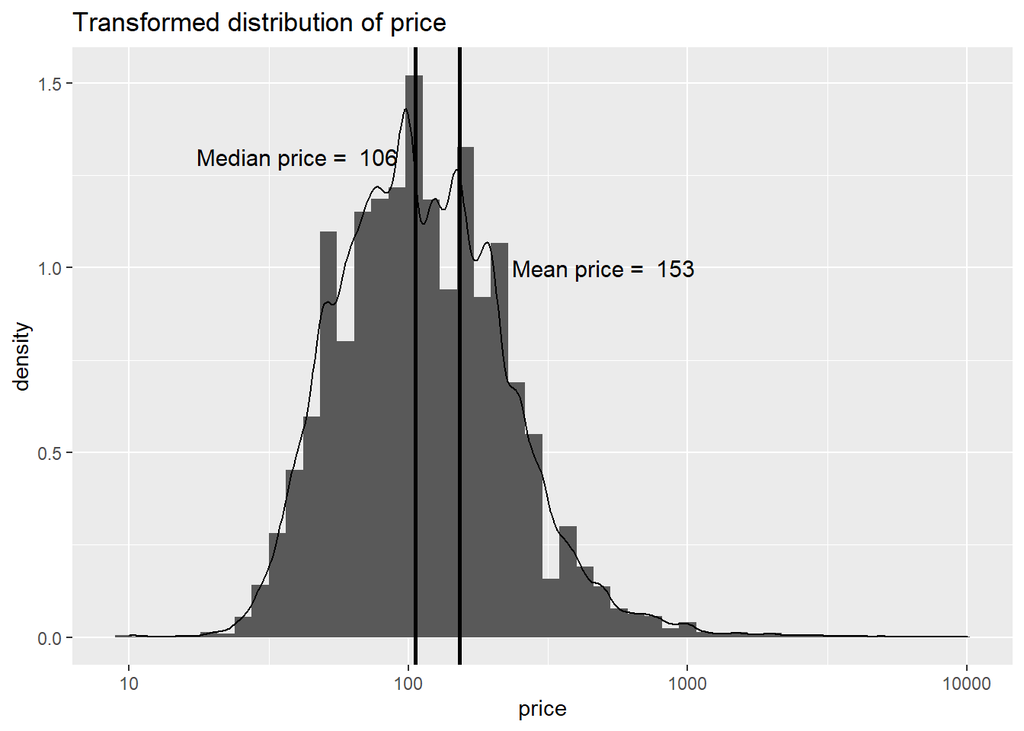

```r
ggplot(bnb, mapping = aes(x = price)) +
        geom_histogram(bins = 50, aes(y = ..density..)) +
        geom_density(alpha = 0.2) +
        ggtitle("Transformed distribution of price") +
        geom_vline(xintercept = mean(bnb$price), size = 1, linetype = 1)+
        annotate("text", x = 500, y = 1,label = paste("Mean price = ",round((mean(bnb$price)))),color =  "black", size = 4)+
        geom_vline(xintercept = median(bnb$price), size = 1, linetype = 1)+
        annotate("text", x = 40, y = 1.3,label = paste("Median price = ",median(bnb$price)), color =  "black", size = 4)+
        scale_x_log10()
```

From the histogram, we can tell that the median price is 106 dollar and mean price is 153 dollar.

# 3.2 Histogram and Frequency Distribution of neighbourhood areas

```r
freq_location <- data.frame(cbind(Frequency = table(bnb$neighbourhood_group), Percent = prop.table(table(bnb$neighbourhood_group)) * 100))
freq_location <- freq_location[order(freq_location$Frequency),]
freq_location
```

```
##               Frequency    Percent
## Staten Island       373  0.7630308
## Bronx              1090  2.2297684
## Queens             5666 11.5907045
## Brooklyn          20095 41.1075198
## Manhattan         21660 44.3089764
```

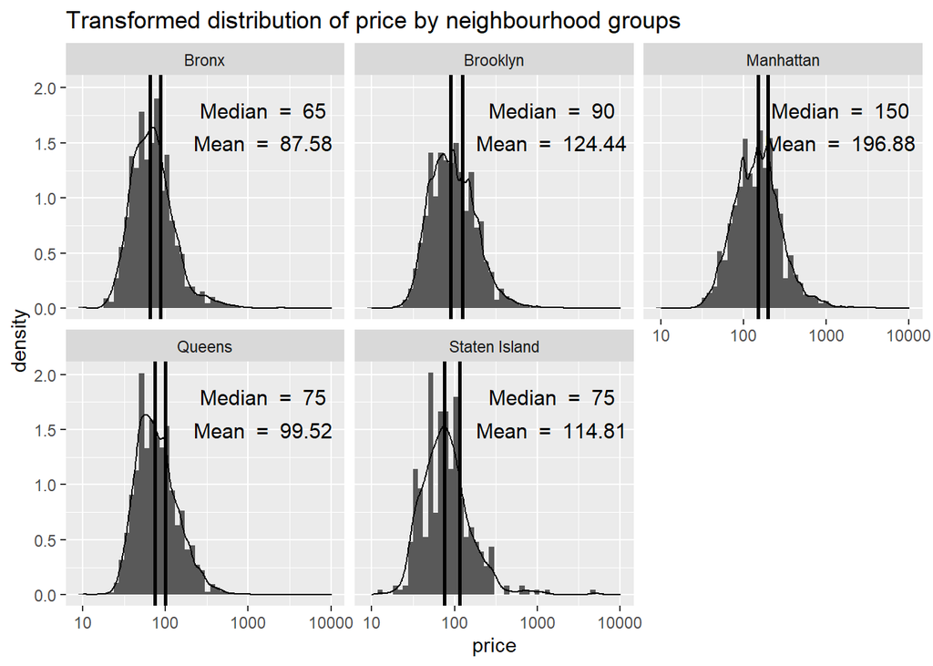

```r
airbnb_nh_mean <- bnb %>%
    group_by(neighbourhood_group) %>%
    summarise(price = round(mean(price), 2))

airbnb_nh_median <- bnb %>%
  group_by(neighbourhood_group) %>%
  summarise(price = median(price))


ggplot(bnb, aes(price)) +
    geom_histogram(bins = 50, aes(y = ..density..)) +
    geom_density(alpha = 0.2) +
    ggtitle("Transformed distribution of price by neighbourhood groups",) +

     geom_vline(data = airbnb_nh_mean, aes(xintercept = price), size = 1, linetype = 1)+

        geom_text(data = airbnb_nh_mean,y = 1.5, aes(x = 1500, label = paste("Mean  = ",price)), color = "black", size = 4) +


    geom_vline(data = airbnb_nh_median, aes(xintercept = price), size = 1, linetype = 1)+

        geom_text(data = airbnb_nh_median,y = 1.8, aes(x = 1500, label = paste("Median  = ",price)), color = "black", size = 4)+

    facet_wrap(~neighbourhood_group) +
    scale_x_log10()
```

```r
airbnb_nh_median
```

```
## # A tibble: 5 x 2
##   neighbourhood_group price
##   <chr>               <dbl>
## 1 Bronx                  65
## 2 Brooklyn               90
## 3 Manhattan             150
## 4 Queens                 75
## 5 Staten Island          75
```

From the graph, we can get that 85% of Airbnb listings are located in Brooklyn and Manhattan, which means that there is more demand since Brooklyn is the most populous neighbourhood and Manhattan is the center of NYC.

*Manhattan (average price of 196.88 dollars, median price of 150 dollars)

*Brooklyn (average price of 124.44 dollars, median price of 90 dollars)

*Queens (average price of 99.52 dollars, median price of 75 dollars)

*Bronx (average price of 87.58 dollars, median price of 65 dollars)

*Staten Island (average price of $114.81 dollars, median price of 75 dollars)

# 3.3 Boxplots of price by room type

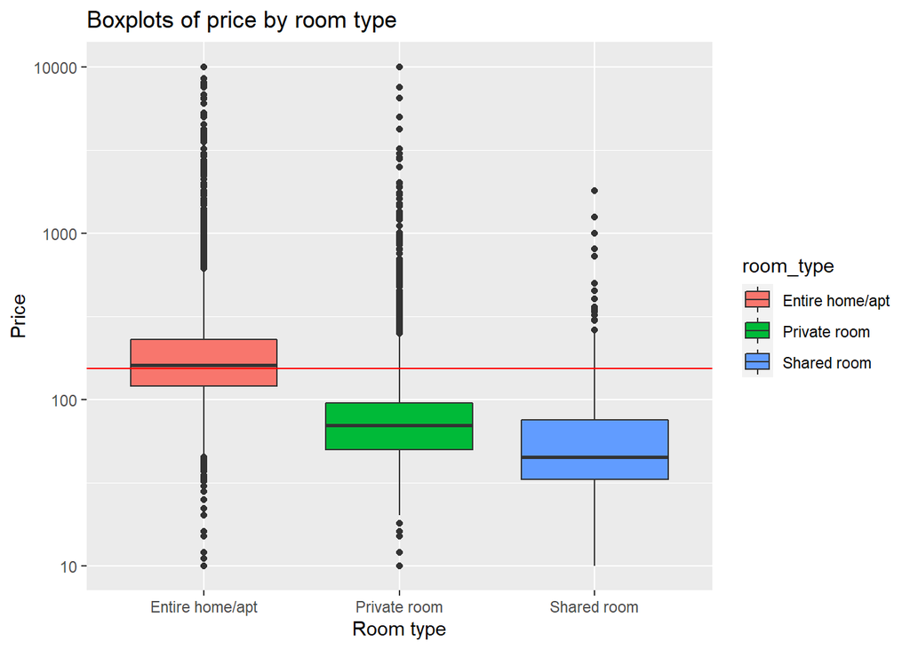

```r
ggplot(bnb, aes(x = room_type, y = price)) +
  geom_boxplot(aes(fill = room_type)) + scale_y_log10() +
  xlab("Room type") +
  ylab("Price") +
  ggtitle("Boxplots of price by room type") +
  geom_hline(yintercept = mean(bnb$price), color = "RED", linetype = 1)
```

# 3.4 Histogram of Room Type by Neighbourhood Group

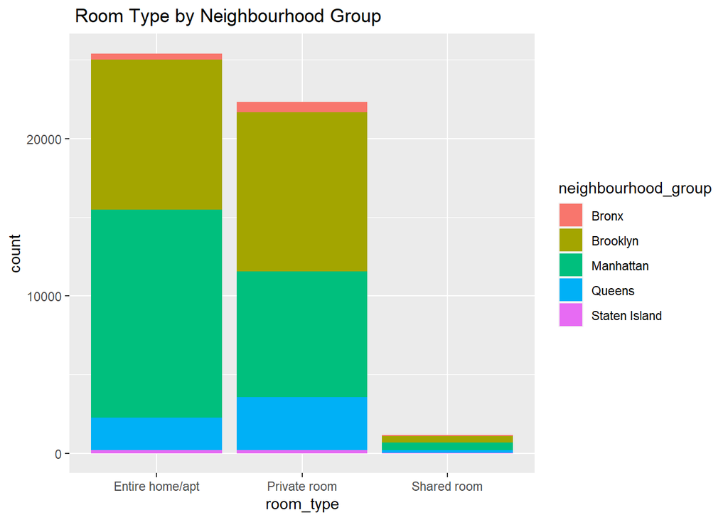

```r
ggplot(bnb, aes(room_type)) + geom_bar(aes(fill = neighbourhood_group)) + ggtitle(" Room Type by Neighbourhood Group")
```

From the plot, we can tell the distribution of room type in each Neighborhood Group, most of the listings Airnbn available in NYC are entire homes/apartments and private, shared room only takes a minor part.

# 3.5 Relation between longitude and price and visualization

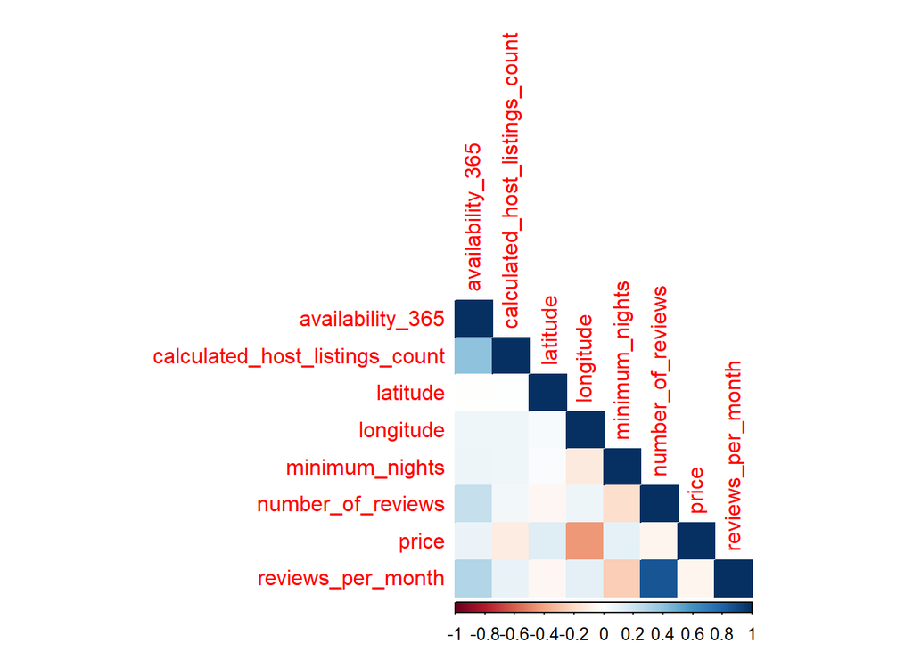

```r
airbnb_cor <- bnb[, sapply(bnb, is.numeric)]
airbnb_cor <- airbnb_cor[complete.cases(airbnb_cor), ]
correlation_matrix <- cor(airbnb_cor, method = "spearman")
corrplot(correlation_matrix, method = "color", type ="lower",order = 'alphabet')
```

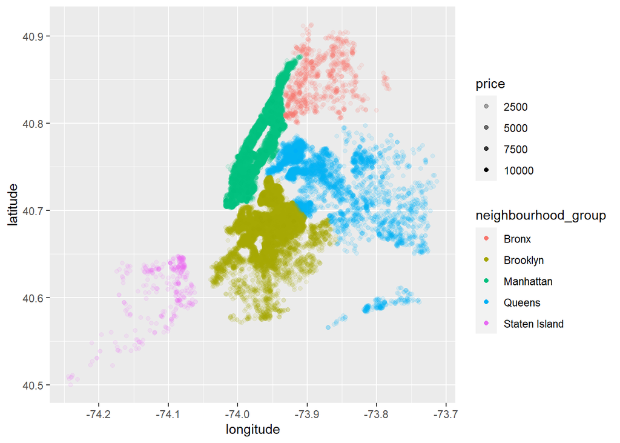

```r
ggplot(bnb,aes(x=longitude,y=latitude,color=neighbourhood_group,alpha=price))+geom_point()
```

From the plot, we can visualize the relation between **price**and**longitude**, we can tell that the neighborhood_group have higher mean price like Manhattan and Brooklyn are concentrated about -74.0 longitude, and as longitude increase,which is far away from these neighborhood_groups, the price will decrease.

# 4 Feature Extraction

In this section, convert all categorical columns into numerical values.

For the column `name`, as it is a column of natural language, it is processed to some columns indicating the occurrence of some keywords, including “large”, “loft”, “modern”, “lux”, “city”, “country”, “village”.

For all other categorical columns, use one-hot encoding to convert these columns into multiple indicator columns. For the columns `host_name`, `neighbourhood` and `neighbourhood_group`, as there are too many possible values, only the top 3 most common values are encoded differently, and the others are encoded as the same.

```r
library(caret)
top.host_name <- head(arrange(count(bnb, host_name), desc(n)), 3)
top.neighbourhood <- head(arrange(count(bnb, neighbourhood), desc(n)), 3)
top.neighbourhood_group <- head(arrange(count(bnb, neighbourhood_group), desc(n)), 3)
# collect the occurrence of each key word in name column
bnb.name <- bnb %>%
  mutate(name = tolower(name)) %>%
  mutate(
    large = as.integer(grepl("large", name)),
    loft = as.integer(grepl("loft", name)),
    modern = as.integer(grepl("modern", name)),
    lux = as.integer(grepl("lux", name)),
    city = as.integer(grepl("city", name)),
    country = as.integer(grepl("country", name)),
    village = as.integer(grepl("village", name)),
  )
bnb.name$name <- NULL
# only use top host_names
bnb.other <- bnb.name %>%
  mutate(
    host_name = if_else(host_name %in% top.host_name$host_name, host_name, "Other"),
    neighbourhood = if_else(neighbourhood %in% top.neighbourhood$neighbourhood, neighbourhood, "Other"),
    neighbourhood_group = if_else(neighbourhood_group %in% top.neighbourhood_group$neighbourhood_group, neighbourhood_group, "Other")
  )
bnb.onehot <- predict(dummyVars("~ .", bnb.other), bnb.other)
bnb.onehot <- as.data.frame(bnb.onehot)
```

```r
dim(bnb.onehot)
```

```
## [1] 48884    30
```

# 5 Data Splitting

The data splitting process consists of two steps:

```r
library(tune)
library(rsample)
library(recipes)

# bnb.onehot <- head(bnb.onehot, 100)

train.test.split <- initial_split(bnb.onehot, prop = 0.8, strata = price)
train <- training(train.test.split)
test <- testing(train.test.split)
cv <- vfold_cv(bnb.onehot, v = 5, strata = price)

bnb.recipe <- recipe(price ~ ., data = train)
dim(train)
```

```
## [1] 39105    30
```

# 6 Model Fitting

## 6.1 Boosted Trees

The first examined model is boosted tree. The implementation of xgboost is adopted. Xgboost approach repeatedly train decision trees to fill the gap between current predictions with the groud-truth target values.

For xgboost, the parameter `mtry` is tuned to achieve the best performance. It controls the number of sampled predictors at each tree split.

```r
library(parsnip)
library(workflows)
library(xgboost)
bt.model <- boost_tree(mode = "regression", mtry = tune())
bt.workflow <- workflow(bnb.recipe, bt.model)
bt.tune <- tune_grid(bt.workflow, resamples = cv, grid = 5)
save(bt.tune, bt.workflow, file="./script/bt.tune.rda")
collect_metrics(bt.tune)
```

```
## # A tibble: 10 x 7
##     mtry .metric .estimator    mean     n  std_err .config
##    <int> <chr>   <chr>        <dbl> <int>    <dbl> <chr>
##  1    24 rmse    standard   222.        5 10.3     Preprocessor1_Model1
##  2    24 rsq     standard     0.150     5  0.0166  Preprocessor1_Model1
##  3     8 rmse    standard   219.        5 10.1     Preprocessor1_Model2
##  4     8 rsq     standard     0.164     5  0.0144  Preprocessor1_Model2
##  5    20 rmse    standard   221.        5 10.5     Preprocessor1_Model3
##  6    20 rsq     standard     0.150     5  0.0156  Preprocessor1_Model3
##  7     2 rmse    standard   224.        5  9.91    Preprocessor1_Model4
##  8     2 rsq     standard     0.129     5  0.00844 Preprocessor1_Model4
##  9    14 rmse    standard   221.        5 10.5     Preprocessor1_Model5
## 10    14 rsq     standard     0.152     5  0.0168  Preprocessor1_Model5
```

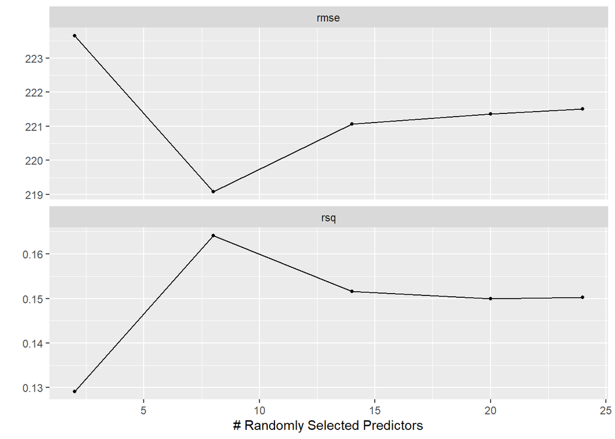

```r
autoplot(bt.tune)
```

## 6.2 Linear regression

Then linear regression is tested on the dataset. Linear regression fits a linear function which minimize the L2 loss on the training set. The backend engine is chosen as `glmnet`, as it provides both L1 (`mixture`) and L2 (`penalty`) penalty terms to tune. The weights of the two penalty terms are both tuned to achieve the best performance.

```r
library(parsnip)
library(workflows)
lm.model <- linear_reg(engine = "glmnet", penalty = tune(), mixture = tune())
lm.workflow <- workflow(bnb.recipe, lm.model)
lm.tune <- tune_grid(lm.workflow, resamples = cv, grid = 5)
save(lm.tune, lm.workflow, file="./script/lm.tune.rda")
collect_metrics(lm.tune)
```

```
## # A tibble: 10 x 8
##          penalty mixture .metric .estimator    mean     n  std_err .config
##            <dbl>   <dbl> <chr>   <chr>        <dbl> <int>    <dbl> <chr>
##  1 0.00000000793  0.0783 rmse    standard   226.        5 10.1     Preprocessor~
##  2 0.00000000793  0.0783 rsq     standard     0.106     5  0.00543 Preprocessor~
##  3 0.599          0.344  rmse    standard   226.        5 10.1     Preprocessor~
##  4 0.599          0.344  rsq     standard     0.106     5  0.00545 Preprocessor~
##  5 0.0000000654   0.558  rmse    standard   226.        5 10.1     Preprocessor~
##  6 0.0000000654   0.558  rsq     standard     0.106     5  0.00543 Preprocessor~
##  7 0.000133       0.701  rmse    standard   226.        5 10.1     Preprocessor~
##  8 0.000133       0.701  rsq     standard     0.106     5  0.00543 Preprocessor~
##  9 0.00000115     0.837  rmse    standard   226.        5 10.1     Preprocessor~
## 10 0.00000115     0.837  rsq     standard     0.106     5  0.00543 Preprocessor~
```

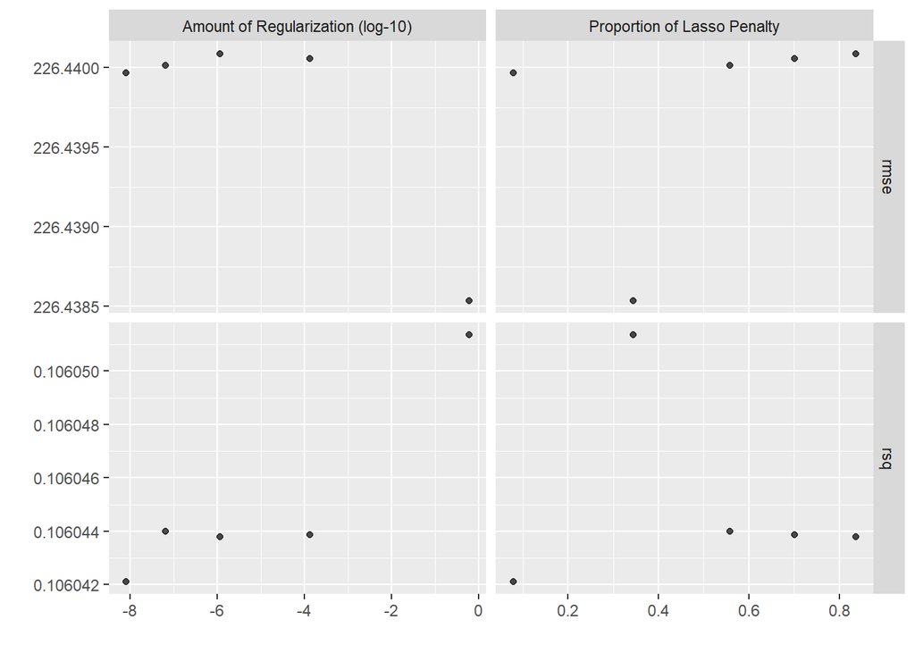

```r
autoplot(lm.tune)
```

## 6.3 Support Vector Machine

The third model tuned is Support Vector Machine (SVM). SVM also fits a linear function to the training data. Though it tries to maximize the margin between data with different labels, instead of to minimize the L2 loss. For SVM model, `cost` and `margin` are tuned. `cost` weighs the cost of mis-predicted samples, while `margin` stands for the margin size of un-penalized region.

```r
library(parsnip)
library(workflows)
svm.model <- svm_linear(mode = "regression", cost = tune(), margin = tune())
svm.workflow <- workflow(bnb.recipe, svm.model)
svm.tune <- tune_grid(svm.workflow, resamples = cv, grid = 5)
save(svm.tune, svm.workflow, file="./script/svm.tune.rda")
collect_metrics(svm.tune)
```

```
## # A tibble: 10 x 8
##       cost margin .metric .estimator     mean     n  std_err .config
##      <dbl>  <dbl> <chr>   <chr>         <dbl> <int>    <dbl> <chr>
##  1 0.534   0.116  rmse    standard   238.         5 10.2     Preprocessor1_Mode~
##  2 0.534   0.116  rsq     standard     0.0127     5  0.00156 Preprocessor1_Mode~
##  3 0.143   0.143  rmse    standard   238.         5 10.2     Preprocessor1_Mode~
##  4 0.143   0.143  rsq     standard     0.0127     5  0.00156 Preprocessor1_Mode~
##  5 9.84    0.0146 rmse    standard   238.         5 10.2     Preprocessor1_Mode~
##  6 9.84    0.0146 rsq     standard     0.0127     5  0.00156 Preprocessor1_Mode~
##  7 0.0189  0.0692 rmse    standard   238.         5 10.2     Preprocessor1_Mode~
##  8 0.0189  0.0692 rsq     standard     0.0127     5  0.00156 Preprocessor1_Mode~
##  9 0.00344 0.180  rmse    standard   238.         5 10.2     Preprocessor1_Mode~
## 10 0.00344 0.180  rsq     standard     0.0127     5  0.00156 Preprocessor1_Mode~
```

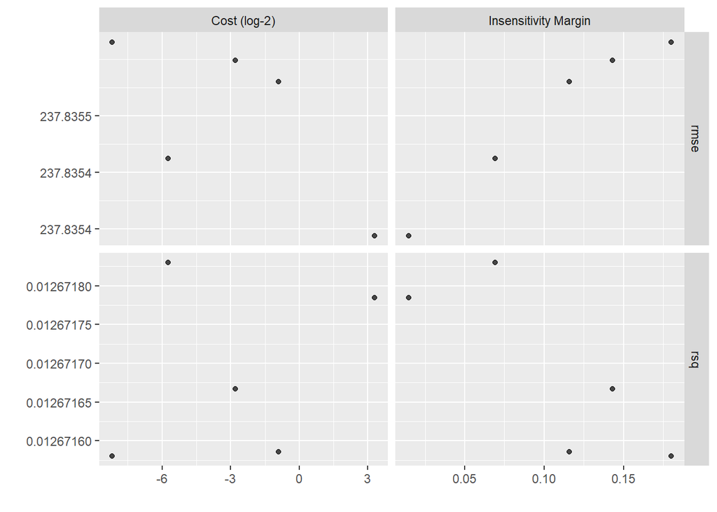

```r
autoplot(svm.tune)
```

## 6.4 Neural Network (Multi-Layer Perceptron)

The last model is neural network, more specifically, Multi-Layer Perceptron (MLP) model is used. It is a two-layer stack of linear layers, with a `ReLU` activation function in between. It is trained to minimize the L2 loss on the training set. For MLP model, the weight of L2 penalty term is tuned to achieve the best performance.

```r
library(parsnip)
library(workflows)
mlp.model <- mlp(mode = "regression", penalty = tune())
mlp.workflow <- workflow(bnb.recipe, mlp.model)
mlp.tune <- tune_grid(mlp.workflow, resamples = cv, grid = 5)
save(mlp.tune, mlp.workflow, file="./script/mlp.tune.rda")
collect_metrics(mlp.tune)
```

```
## # A tibble: 10 x 7
##     penalty .metric .estimator      mean     n  std_err .config
##       <dbl> <chr>   <chr>          <dbl> <int>    <dbl> <chr>
##  1 2.92e- 3 rmse    standard   239.          5 10.2     Preprocessor1_Model1
##  2 2.92e- 3 rsq     standard     0.00421     1 NA       Preprocessor1_Model1
##  3 8.62e- 2 rmse    standard   239.          5 10.3     Preprocessor1_Model2
##  4 8.62e- 2 rsq     standard     0.0119      2  0.0119  Preprocessor1_Model2
##  5 8.15e- 5 rmse    standard   235.          5 11.4     Preprocessor1_Model3
##  6 8.15e- 5 rsq     standard     0.0965      2  0.00603 Preprocessor1_Model3
##  7 2.61e- 7 rmse    standard   234.          5  9.74    Preprocessor1_Model4
##  8 2.61e- 7 rsq     standard     0.0722      3  0.0176  Preprocessor1_Model4
##  9 3.87e-10 rmse    standard   236.          5  8.94    Preprocessor1_Model5
## 10 3.87e-10 rsq     standard     0.0486      3  0.0183  Preprocessor1_Model5
```

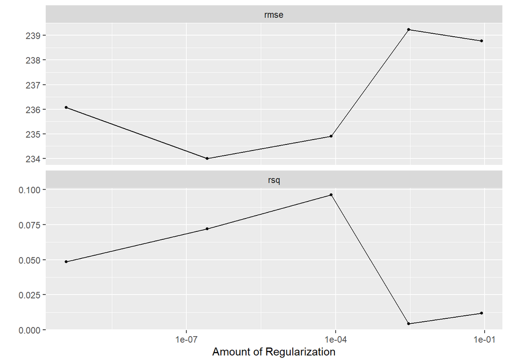

```r
autoplot(mlp.tune)
```

## 6.5 Model selection

```r
bt.rmse <- min(filter(collect_metrics(bt.tune), .metric == "rmse")["mean"])
lm.rmse <- min(filter(collect_metrics(lm.tune), .metric == "rmse")["mean"])
svm.rmse <- min(filter(collect_metrics(svm.tune), .metric == "rmse")["mean"])
mlp.rmse <- min(filter(collect_metrics(mlp.tune), .metric == "rmse")["mean"])
model.metrics <- data.frame(
  model = c("boosted tree", "linear regression", "svm", "neural network"),
  best.RMSE = c(bt.rmse, lm.rmse, svm.rmse, mlp.rmse)
)
model.metrics
```

```
##               model best.RMSE
## 1      boosted tree  219.0755
## 2 linear regression  226.4385
## 3               svm  237.8353
## 4    neural network  233.9953
```

So, the boosted trees is chosen as the final model to be tested on the test set. Finally, the RMSE on the test set is calculated.

```r
best.mtry <- arrange(filter(collect_metrics(bt.tune), .metric == "rmse"), mean)$mtry[1]
best.model <- boost_tree(mode = "regression", mtry = best.mtry)
best.workflow <- workflow(bnb.recipe, best.model)
best.predictor <- fit(best.workflow, data = train)
test$prediction <- predict(best.predictor, test)$.pred
sqrt(mean((test$prediction - test$price) ** 2))
```

```
## [1] 216.4821
```

# 7. Conclusion

Among all the four tested models, the boosted tree performs the best, while the SVM model performs the most poorly. The results are as expected because boosted tree is much more representative than linear models including linear regression and SVM, and it achieves better performance by aggregating multiple basic tree models. SVM performs worse than linear regression as expected, because linear regression optimizes L2 loss directly, which matches the direction of RMSE metric. At last, MLP model achieves worse performance than linear regression. The reason could be the complexity of MLP model and thus it is over-fitted to the training set, compared to simple linear models.

Generally, the chosen models could all make sensible predictions for the price predicting problem. Given the price range being from 0 to 10000, it is accurate to make a prediction with absolute error within 250. The value of RMSE indicates such scale of absolute errors.

There are some work remain for next steps. They are listed below.

- Explore more possible features. For now, the information of some features like `host_name` and `neighborhood` is highly compressed by only reckon a small part of their values. Maybe more information could be leveraged from them.
- Process natural language in `name` column. It may be good to extract semantic information from texts using techniques like bag of words or recurrent neural networks.
- Further tune the hyper-parameter of models. Due to the time limit, only a part of hyper-parameters are tuned, and only for a part of possible values. If given more time to tune the model, it may achieve better performance.